# Berechnung der 7-Tag-Inzidenz Berlin und RKI

LAGeSo Berlin Infektionsschutz (I C 1)

2020-10-26

# Einleitung

Im Folgenden wird die Berechnung der COVID-19 7-Tage-Inzidenz für Berlin durch das LAGeSo und das RKI erklärt. Für die gezeigte Berechnung werden nur öffentlich zugängliche Datenquellen verwendet, damit jeder Schritt selbständig nachvollzogen werden kann.

Diese HTML-Datei (.nb.html) kann direkt in RStudio geöffnet und ausgeführt werden, um die Berechnungen mit aktuellen Daten durchzuführen.

# Datumsangaben

Jeder gemeldete Fall am LAGeSo besitzt drei verschiedene Datumsangaben:

1. Erkrankungsdatum: Dieses Datum wird durch die Gesundheitsämter erfragt und spiegelt das Datum der ersten Symptome eines Falles wieder. Mithilfe des Erkrankungsdatums kann der Ansteckungszeitpunkt genauer abgeschätzt werden. Es ist häufig bei der Erstübermittlung des Falles noch nicht vorhanden. Bei asymptomatischen Fällen gibt es kein Erkrankungsdatum und bei manchen Fällen kann das Erkrankungsdatum nicht ermittelt werden.
2. Meldedatum: Als Meldedatum wird in der, vom Robert Koch-Institut (RKI) zur Verfügung gestellten, elektronischen Software „SurvNet@RKI“, die in Berlin von allen Gesundheitsämtern verwendet wird, standardmäßig das aktuelle Datum bei Anlegen des Falles beim Gesundheitsamt eingesetzt. In einigen Fällen wird dieses Datum jedoch, auf das Datum an dem das Gesundheitsamt die Meldung erhalten hat, geändert.
3. Berichtsdatum: Das Berichtsdatum ist das Datum des Datenstandes des Lageberichts des LAGeSo. Dieses Datum kann sich vom Meldedatum unterscheiden.

Eine ausführlichere Erklärung finden Sie im Info-Tab unseres [Lageberichts.](https://www.berlin.de/corona/lagebericht/desktop/corona.html#info)

# Berechnung (Anleitung beginnt hier)

## Bibliotheken laden

```r
library(tidyverse)
library(zoo)
```

## Daten laden

### Berliner Fallzahlen nach Meldedatum

Die Fallzahlen der Berliner Bezirke nach Meldedatum werden durch das LAGeSo auf dem OpenData-Portal von Berlin (https://daten.berlin.de) veröffentlicht.

Link: https://daten.berlin.de/datensaetze/covid-19-berlin-verteilung-den-bezirken-gesamt%C3%BCbersicht

```r
Faelle_nach_Meldedatum_und_Bezirken_Berlin <- read.csv2(
  "https://www.berlin.de/lageso/gesundheit/infektionsepidemiologie-infektionsschutz/corona/tabelle-bezirke-gesamtuebersicht/index.php/index/all.csv"
  )
```

Da diese Daten auf Bezirksebene vorliegen, summieren wir die Bezirksfallzahlen auf um die Fallzahl für Berlin zu erhalten.

```r
Faelle_nach_Meldedatum_und_Bezirken_Berlin %>%
  # Datensatz von Wide nach Long umwandeln
  pivot_longer(mitte:reinickendorf, names_to = "Bezirk", values_to = "Faelle_LAGeSo") %>%
  # Datum parsen und umbenennen
  mutate(Meldedatum = as.Date(datum)) %>%
  # Zusammenfassen der Bezirke
  group_by(Meldedatum) %>%
  summarise(Faelle_LAGeSo = sum(Faelle_LAGeSo)) -> Faelle_nach_Meldedatum_Berlin
```

### RKI Fallzahlen

Die Fallzahlen RKI werden als OpenData-Datensatz veröffentlicht. Dieser dient als Datenquelle für das RKI Covid-19-Dashboard.

Link: https://www.arcgis.com/home/item.html?id=f10774f1c63e40168479a1feb6c7ca74

```r
RKI_Fallzahlen_in_Deutschland <- read.csv("https://www.arcgis.com/sharing/rest/content/items/f10774f1c63e40168479a1feb6c7ca74/data")

# Alternative 2
#RKI_Fallzahlen_in_Deutschland <- read.csv("https://opendata.arcgis.com/datasets/dd4580c810204019a7b8eb3e0b329dd6_0.csv")
```

Auch bei diesem Datensatz müssen wir die Fallzahlen nach Meldedatum für Berlin aufsummieren.

```r
RKI_Fallzahlen_in_Deutschland %>%
  # Nur die Fälle aus Berlin verwenden
  filter(Bundesland == "Berlin") %>%
  # Siehe Datensatzbeschreibung des RKI
  filter(NeuerFall %in% 0:1) %>%
  # Zusammenfassen der Bezirke
  group_by(Meldedatum) %>%
  summarise(Faelle_RKI = sum(AnzahlFall)) %>%
  # Datum parsen
  mutate(Meldedatum = as.Date(Meldedatum)) -> RKI_Faelle_nach_Meldedatum_Berlin
```

## Datensätze zusammenfügen

Als nächstes fügen wir die Fallzahlen des LAGeSo und des RKI anhand des Meldedatums zusammen um sie besser vergleichen zu können.

```r
Vergleich_Faelle <- full_join(Faelle_nach_Meldedatum_Berlin,
                              RKI_Faelle_nach_Meldedatum_Berlin,
                              by = c("Meldedatum" = "Meldedatum"))
```

Mithilfe des Paketes “zoo” wird die 7-Tage-Fallzahl berechnet. Die Funktion `rollsumr` summiert dabei die Fälle mit einem gleitenden 7 Tage Fenster auf.

```r
Vergleich_Faelle %>%
  arrange(Meldedatum) %>%
  mutate(
    Faelle_7Tage_LAGeSo = zoo::rollsumr(Faelle_LAGeSo, k = 7, na.pad = TRUE),
    Faelle_7Tage_RKI    = zoo::rollsumr(Faelle_RKI,    k = 7, na.pad = TRUE, na.rm = TRUE),
  ) -> Vergleich_Faelle
Vergleich_Faelle %>% arrange(desc(Meldedatum))
```

| Meldedatum | Faelle_LAGeSo | Faelle_RKI | Faelle_7Tage_LAGeSo | Faelle_7Tage_RKI |
| --- | --- | --- | --- | --- |
| 2020-11-03 | 1312 | 538 | 6879 | 6104 |
| 2020-11-02 | 1423 | 1422 | 6713 | 6713 |
| 2020-11-01 | 364 | 365 | 6312 | 6313 |
| 2020-10-31 | 361 | 361 | 6279 | 6279 |
| 2020-10-30 | 1077 | 1076 | 6199 | 6199 |
| 2020-10-29 | 1046 | 1046 | 6052 | 6053 |
| 2020-10-28 | 1296 | 1296 | 5912 | 5915 |
| 2020-10-27 | 1146 | 1147 | 5432 | 5435 |
| 2020-10-26 | 1022 | 1022 | 5187 | 5189 |
| 2020-10-25 | 331 | 331 | 4945 | 4947 |

[output cut: 236 more lines]

Man sieht, dass die Fallzahlen zwischen LAGeSo und dem RKI nahe dem “jetzt” erheblich abweichen können. Geht man aber einige Tage zurück sind die Fallzahlen identisch.

### Vergleich der 7-Tage-Fallzahl

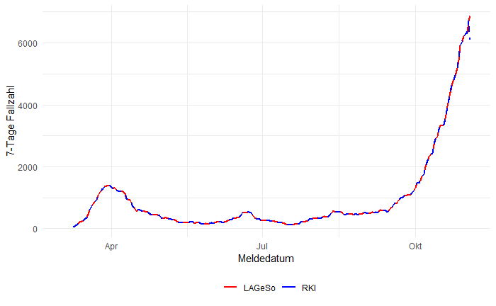

```r
ggplot(Vergleich_Faelle, aes(x = Meldedatum)) +
  geom_line(aes(y = Faelle_7Tage_LAGeSo, color = "LAGeSo"), size = 1) +
  geom_line(aes(y = Faelle_7Tage_RKI, color = "RKI"), linetype = 2, size = 1) +
  scale_color_manual(
    values = c("LAGeSo" = "red", "RKI" = "blue"),
    guide = guide_legend(title = NULL)
  ) +
  ylab("7-Tage Fallzahl") +
  theme_minimal()+
  theme(legend.position = "bottom")
```

**Vergleich der 7-Tage-Fallzahl des LAGeSo und des RKI**

### Vergleich der täglichen Fallzahl

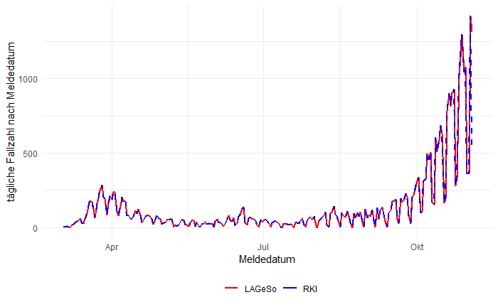

```r
ggplot(Vergleich_Faelle, aes(x = Meldedatum)) +
  geom_line(aes(y = Faelle_LAGeSo, color = "LAGeSo"), size = 1) +
  geom_line(aes(y = Faelle_RKI, color = "RKI"), linetype = 2, size = 1) +
  scale_color_manual(
    values = c("LAGeSo" = "red", "RKI" = "blue"),
    guide = guide_legend(title = NULL)
  ) +
  ylab("tägliche Fallzahl nach Meldedatum") +
  theme_minimal() +
  theme(legend.position = "bottom")
```

**Vergleich der täglichen Fallzahl des LAGeSo und des RKI**

# Erklärung

**Vorgaben zur Übermittlung nach dem Infektionsschutzgesetz**

> Gemäß §11(1) Infektionsschutzgesetz übermitteln die zuständigen Gesundheitsämter die verarbeiteten Daten zu meldepflichtigen Krankheiten und Nachweisen von Krankheitserregern, also auch Nachweise von SARS-CoV-2, spätestens am folgenden Arbeitstag nichtnamentlich an die zuständige Landesbehörde - in Berlin an das LAGeSo. Von dort müssen die Daten spätestens am folgenden Arbeitstag an das Robert Koch-Institut (RKI) übermittelt werden.

Um die politischen Entscheidungsträger in Berlin zeitnah und tagesaktuell informieren zu können, ist der Datenstand vom LAGeSo auf 12:00 Uhr festgelegt. Es besteht daher die Bitte an die Berliner Gesundheitsämter, die bei Ihnen vorliegenden und verarbeiteten Meldedaten täglich bis zu diesem Zeitpunkt an das LAGeSo zu übermitteln. Die Gesundheitsämter werden zusätzlich einzeln gegen ca. 11:45 Uhr erinnert, falls von Ihnen bis dahin noch keine Datenlieferung an das LAGeSo erfolgt ist. Die an das LAGeSo übermittelten Daten werden einmal am Tag, zwischen 12:00 und 13:00 Uhr an das RKI übermittelt.

Da die Datengrundlage gleich ist, kann es aus 2 Gründen zu Abweichungen in der 7-Tage-Inzidenz kommen:

1. Unterschiede im gewählten Intervall für die Berechnung der 7-Tage-Fallzahl
2. Unterschiede in der Einwohner*innenzahl für Berlin, aufgrund der Verwendung unterschiedlicher Datenquellen.

## Erklärung zum 7-Tage-Intervall

Bei der Berechnung der 7-Tage-Inzidenz des LAGeSo werden die Fallzahlen mit Meldedatum des aktuellen Berichtstags nicht verwendet, da diese noch nicht vollständig sind. Dieser Effekt tritt unseres Wissens nach in allen Bundesländern auf.

Im Vergleich mit unseren [älteren Lageberichten](http://web.archive.org/web/*/www.berlin.de/corona/lagebericht/desktop/corona.html) sieht man, dass die nachträgliche Korrektur der 7-Tage-Fallzahl im einstelligen Bereich liegt. Die folgende Tabelle stellt dar, welche Tage (+) für das 7-Tage-Intervall benutzt werden.

**Tabelle 1: Verwendete Tage für die 7-Tage-Inzidenz**

|  | -7 | -6 | -5 | -4 | -3 | -2 | -1 | neuestes vorliegendes Meldedatum |
| --- | --- | --- | --- | --- | --- | --- | --- | --- |
| LAGeSO | + | + | + | + | + | + | + |  |
| RKI |  | + | + | + | + | + | + | + |

Das RKI berechnet die 7-Tage-Inzidenz unter Verwendung der Fallzahlen des neuesten Meldedatums, für das Daten vorliegen. Dies führt zu einer aktuelleren Inzidenz, welche jedoch stärker nachträglichen Korrekturen unterliegt. Dieser Unterschied ist sichtbar, wenn dieses Skript am frühen Abend ausgeführt wird (siehe folgende Abbildung).

## Erklärung zu den Einwohner*innenzahlen

Das LAGeSo verwendet die [Einwohner*innenregisterstatistik vom 31.12.2019](https://www.statistik-berlin-brandenburg.de/BasisZeitreiheGrafik/Bas-Einwohnerregister.asp?Ptyp=300&Sageb=12041&creg=BBB&anzwer=10) (Quelle: Amt für Statistik Berlin-Brandenburg), nach der Berlin 3.769.495 Einwohner*innen hat. Das RKI verwendet eine Einwohner*innenzahl von 3.669.491 für die Berechnung von Inzidenzen.

$$\frac{3.769.495}{3.669.491} = 1,027$$

Die vom RKI berichtete 7-Tage-Inzidenz ist also 2,7% höher aufgrund von Unterschieden in den verwendeten Einwohner*innenzahlen. Dieser Unterschied ist insgesamt aber nicht relevant, wie man an der folgenden Grafik sieht.

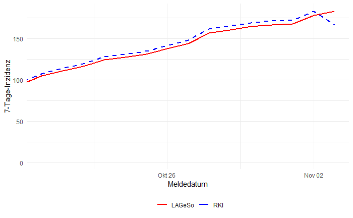

```r
Vergleich_Faelle %>%
  mutate(
    Inzidenz_7T_LAGeSo = (Faelle_7Tage_LAGeSo/3769495)*100000,
    Inzidenz_7T_RKI = (Faelle_7Tage_RKI/3669491)*100000
  ) -> Vergleich_Faelle


ggplot(Vergleich_Faelle, aes(x = Meldedatum)) +
  geom_line(aes(y = Inzidenz_7T_LAGeSo, color = "LAGeSo"), size = 1) +
  geom_line(aes(y = Inzidenz_7T_RKI, color = "RKI"), linetype = 2, size = 1) +
  scale_color_manual(
    values = c("LAGeSo" = "red", "RKI" = "blue"),
    guide = guide_legend(title = NULL)
  ) +
  ylab("7-Tage-Inzidenz") +
  # Zeige letzte 14 Tage
  coord_cartesian(xlim = c(max(Vergleich_Faelle$Meldedatum)-14, NA)) +
  theme_minimal() +
  theme(legend.position = "bottom")
```

Zum Vergleich erhählt man alle vom RKI in Lageberichten veröffentlichten 7-Tage-Inzidenzen in dieser [Excel-Datei (Arbeitsblatt BL_7-Tage-Inzidenz)](https://www.rki.de/DE/Content/InfAZ/N/Neuartiges_Coronavirus/Daten/Fallzahlen_Kum_Tab.html).

## Verwendung des Berichtsdatums zur Berechnung der 7-Tage-Inzidenz

Eine weitere Alternative, welche von einigen Medien verwendet wird, ist die Berechnung der 7-Tage-Inzidenz auf Basis des Berichtsdatums (also der täglich berichteten Zahl neuer Fälle, siehe Erklärung oben). Durch den Datenschluss um 12 Uhr wird hier ein um 12 Stunden verschobenes 7-Tage-Intervall verwendet. Zusätzlich werden bei dieser Art der Berechnung Fälle berücksichtigt, welche, durch Nachmeldung, vom Meldedatum vor den letzten 7 Tagen liegen und somit nicht mehr Teil des aktuellen Infektionsgeschehens sind. Praktisch wird eine um 12h in die Zukunft verschobene Inzidenz berechnet.

# Contributions

- [Michael Hoehle](https://github.com/hoehleatsu)
- [Sebastian Meyer](https://github.com/bastistician)